# Modelling litter size in Arctic foxes

# 1 Introduction

This document describes the analysis of variation in litter size and early survival of pups in Arctic foxes.

The main objective is to examine the relationship between litter size and mother’s age in the Arctic fox. We will compare data on litter size in wild populations with data from foxes kept in captivity as part of a conservation program. For foxes in captivity, there are also data on pup survival until weening and the relationship between pup survival and mother’s age is examined.

The most important prey for Arctic foxes in the wild is lemmings and other species of small rodents. The cyclic variations in the populations of small rodents create large variations in availability of prey between years. In contrast, foxes in the captive breeding station are fed every day and thus experience no variation in food resources between years and seasons.

# 2 Litter size

## 2.1 Data description

For the *wild populations*, data on litter size were only recorded for breeding events that actually produced pups and where the pups were observed after emerging from the den. The data does not include information about unsuccessful breeding events or foxes that did not breed at all. Hence, these data are zero-truncated. Litter size data of *captive foxes* include zeros, but for comparison with *wild foxes*, we have fitted a zero-truncated model also for these data. This implies that we have modelled the variation in litter size conditional on reproducing (having at least one pup that survived until marking.

For the captive foxes, we may also model the probability of producing a litter (Bernoulli model).

In both data sets, there are repeated observations for many of the females (litter size for the same female in different years). To account for this dependence, we will include the random effect ‘mother ID’.

In the dataset for wild foxes, the predictor variable ‘rodent index’ varies among years and areas. Since there are many observations within each combination of year and area, we included ‘area_year’ as a random effect to avoid pseudoreplication.

The two random effects (‘mother ID’ and ‘area_year’) are assumed additive.

## 2.2 Models

The model for litter size in wild populations is:

$$\begin{align}
Y_{i,j} & \sim f(\mu_{i,j}, \phi) \\
\log(\mu_{i,j}) & = \beta_1(X_{i,j}) + \beta_2(X_{i,j})^2 + s(R_{j}) +
\delta_i + \epsilon_j \\
\delta_i & \sim N(0, \sigma_\delta) \\
\epsilon_j & \sim N(0, \sigma_\epsilon) \\
\end{align}$$

Litter size in captivity was first analysed using the same model as for the wild population. This initial analysis did not provide any support for a relationship between litter size and the rodent index. The rodent index was therefore omitted from the final model for litter size in captivity.

## 2.3 Data analysis and results

Loading the required packages.

```r
  library(tidyverse)
  library(readxl)
  library(writexl)
  library(glmmTMB)
  library(splines)     # bs function for B-splines
  library(DHARMa)      # functions to check model assumptions
  library(ggeffects)   # ggpredict function for predictions
  library(emmeans)
  library(psych)
  library(ggbeeswarm)  # geom_quasirandom for beeswarmplot
```

Reading in the two data sets.

```r
station <- readRDS('data/litter_size_captive_breeding_station.rds')
wild <- readRDS('data/litter_size_wild_populations.rds')

# Create a new variable representing the random effect of year within area for wild populations
wild$area_year <- as.factor(paste(wild$mountain_area, wild$year, sep="_"))
```

### 2.3.1 Litter size in wild populations

**Fitting model**

```r
library(glmmTMB)
library(splines)  # bs function for B-splines

### Fit polynomial model for wild populations
fit_wild <- glmmTMB(litter_size ~  poly(mother_age, 2) +
                      bs(rodent_index, 3) +
                      (1|mother_id) + (1|area_year),
                      data = wild,
                      family=truncated_compois)
```

The assumptions for the model were checked using the DHARMa package (for details, see code in Quarto source file).

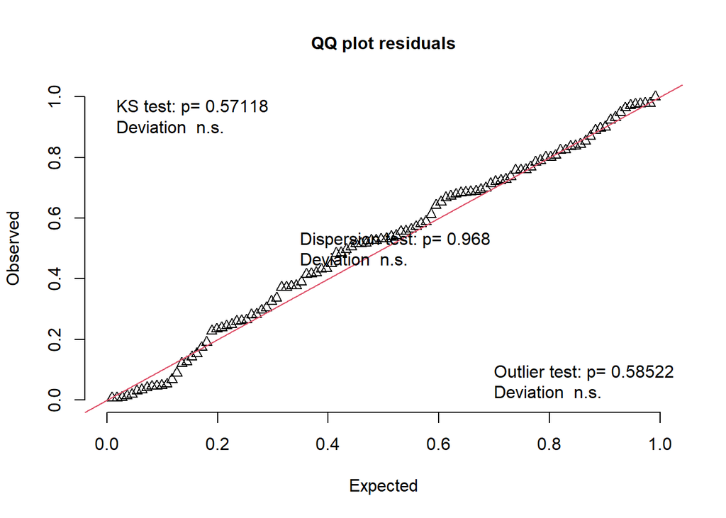

```r
plotQQunif(fit_wild)
```

Predictions are calculated for each mother age from 1 to 8 keeping the rodent index equal to median value of the variable. Random effects are ignored by using the argument type = ‘fixed’.

```r
(pw <- ggpredict(fit_wild, terms="mother_age [all]",
                 type = 'fixed',
                 condition = c(rodent_index = 4))) # median value for rodent_index = 4
```

```
# Predicted values of litter_size

mother_age | Predicted |       95% CI
-------------------------------------
         1 |      4.49 | [3.19, 6.31]
         2 |      4.99 | [4.02, 6.20]
         3 |      5.27 | [4.39, 6.33]
         4 |      5.29 | [4.29, 6.51]
         5 |      5.04 | [3.90, 6.53]
         6 |      4.57 | [3.26, 6.42]
         7 |      3.94 | [2.45, 6.33]
         8 |      3.22 | [1.65, 6.32]

Adjusted for:
* mother_id = NA (population-level)
* area_year = NA (population-level)
```

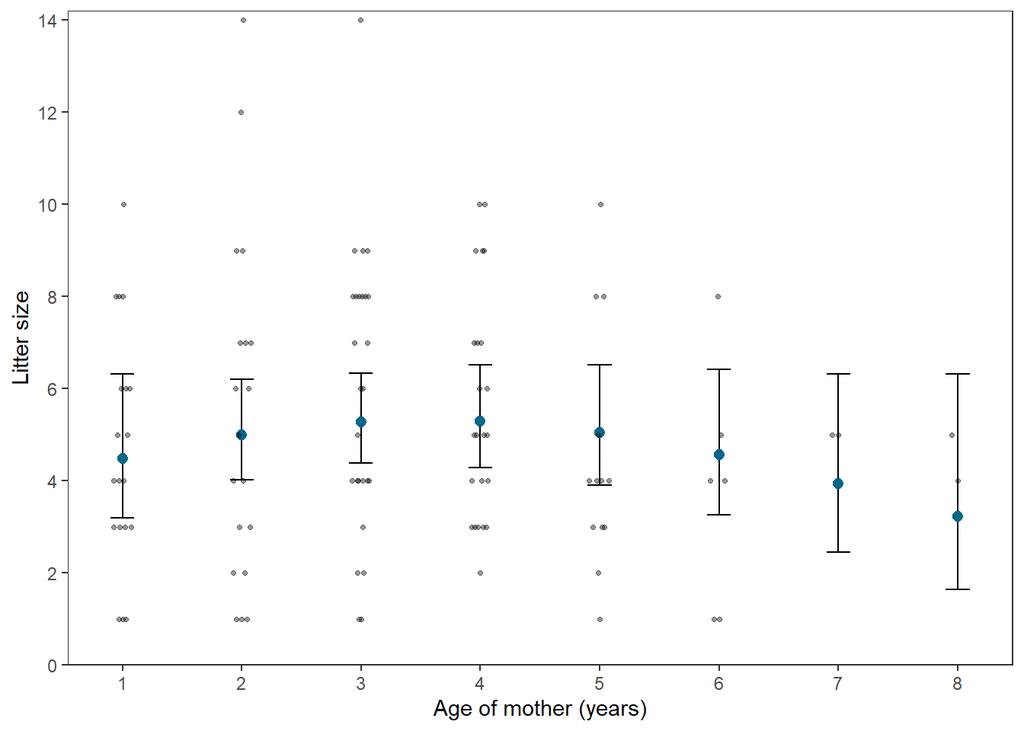

```r
## Plot of predictions with observations
pw |> ggplot(aes(x = x, y = predicted)) +
  geom_errorbar(width = 0.2,
                aes(ymin = conf.low, ymax = conf.high)) +
  geom_point(color = 'deepskyblue4', size = 2.15) +
  scale_y_continuous(limits = c(0, 14.2),
                     expand = c(0, 0),
                     breaks = c(0, 2, 4, 6, 8, 10, 12, 14)) +
  scale_x_continuous(limits = c(0.9, 8.1),
                     breaks = 1:8) +
  labs(y="Litter size", x = "Age of mother (years)") +
  geom_quasirandom(data = wild,
                   mapping=aes(x=mother_age, y= litter_size),
                   alpha = 0.4, size = 0.85, width = 0.1) +
  theme_bw() +
  theme(panel.grid.major.x = element_blank(),
        panel.grid.minor.x = element_blank(),
        panel.grid.major.y = element_blank(),
        panel.grid.minor.y = element_blank())
```

*Figure S2.*

Predictions of litter size in wild populations in response to rodent index:

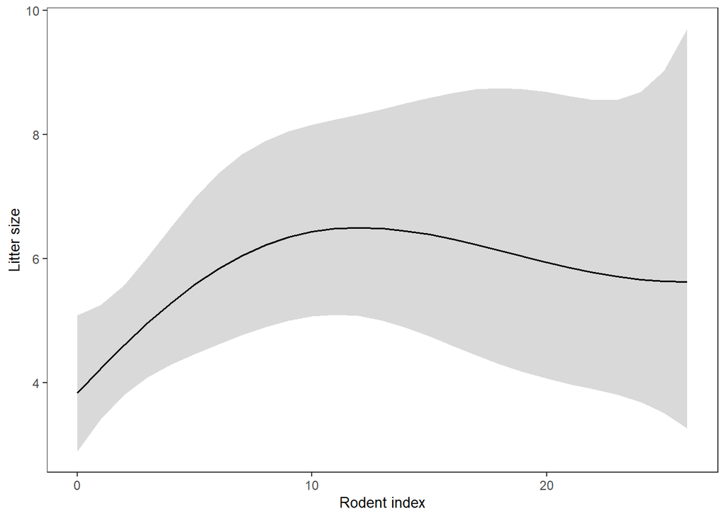

```r
## Predictions of litter size in wild populations in response to rodent index
ggpredict(fit_wild,
          terms = c("rodent_index [0:26.5, by=1]"),
          type = "fixed",
          condition = c(mother_age = 4)) |>
  plot() +
  theme_bw() +
  theme(plot.title = element_blank(),
        panel.grid.major.x = element_blank(),
        panel.grid.minor.x = element_blank(),
        panel.grid.major.y = element_blank(),
        panel.grid.minor.y = element_blank(),
        axis.text.x=element_text(size=9),
        axis.text.y=element_text(size=9),
        axis.title.x = element_text(color = "black", size = 10),
        axis.title.y = element_text(color = "black", size = 10)) +
  labs(x = "Rodent index", y = "Litter size")
```

*Figure S3. Relationship between rodent index and predicted litter size in wild Arctic foxes. The effect of rodent index on litter size is described by a B-spline function.*

### 2.3.2 Litter size in captivity

To make the data on litter size in captivity and wild populations comparable, breeding attempts that did not produce pups are removed prior to analysis.

```r
## Removing zeros for truncated models
station_tr <- station[station$litter_size != 0,]
```

**Fitting models**

```r
### Fit polynomial model for foxes in captivity
fit_captive <- glmmTMB(litter_size ~ poly(mother_age, 2) +
                    (1|mother_id) + (1|year),
                  data = station_tr, family=truncated_compois)
AIC(fit_captive)
```

```
[1] 382.5754
```

AIC value for the model fit_captive is 382.58

We also fitted a model including both mother_age and rodent_index as predictors:

```r
fit_captive_rodents <- glmmTMB(litter_size ~ poly(mother_age, 2) +
                                 bs(rodent_index, 3) +
                                 (1|mother_id) + (1|year),
                  data = station_tr, family=truncated_compois)
```

AIC value for the model fit_captive_rodents is 382.10

The potential relationship between litter size and rodent index can be examined by plotting predicted values for litter size against rodent index:

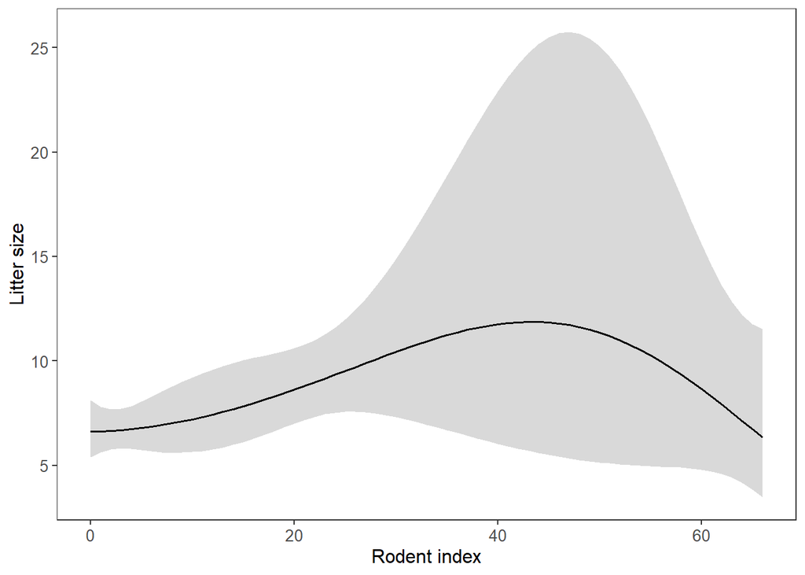

```r
## Predictions of litter size in captivity in response to rodent index
ggpredict(fit_captive_rodents,
          terms = c("rodent_index [0:66, by=1]"),
          type = "fixed",
          condition = c(mother_age = 4)) |>
  plot() +
  theme_bw() +
  theme(plot.title = element_blank(),
        panel.grid.major.x = element_blank(),
        panel.grid.minor.x = element_blank(),
        panel.grid.major.y = element_blank(),
        panel.grid.minor.y = element_blank(),
        axis.text.x=element_text(size=10),
        axis.text.y=element_text(size=10),
        axis.title.x = element_text(color = "black", size = 12),
        axis.title.y = element_text(color = "black", size = 12)) +
  labs(x = "Rodent index", y = "Litter size")
```

Predictions for foxes in captivity.

```r
pc <- ggpredict(fit_captive, terms="mother_age [all]",
                 type = 'fixed')
print(pc, n = Inf)
```

```
# Predicted values of litter_size

mother_age | Predicted |       95% CI
-------------------------------------
         1 |      4.67 | [3.59, 6.07]
         2 |      5.80 | [4.91, 6.85]
         3 |      6.65 | [5.76, 7.69]
         4 |      7.05 | [6.08, 8.18]
         5 |      6.90 | [5.96, 8.00]
         6 |      6.24 | [5.29, 7.36]
         7 |      5.21 | [4.06, 6.70]
         8 |      4.02 | [2.67, 6.07]
         9 |      2.87 | [1.52, 5.42]

Adjusted for:
* mother_id = NA (population-level)
*      year = NA (population-level)
```

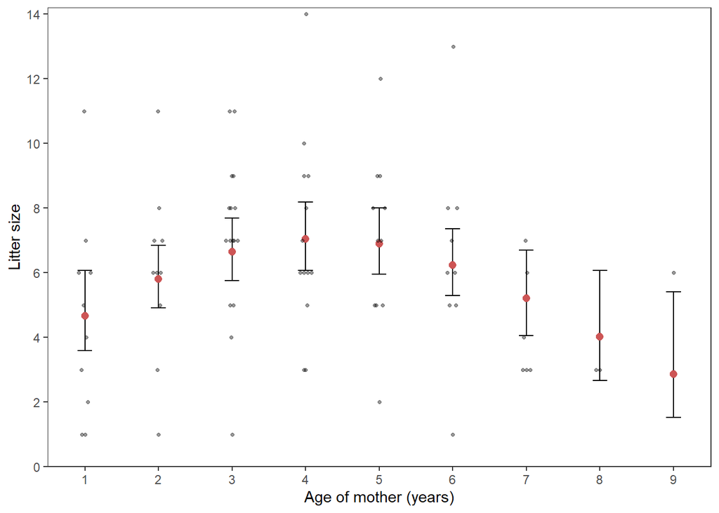

```r
## Predictions for foxes in captivity
pc |> tibble() |> ggplot(aes(x = x, y = predicted)) +
  geom_errorbar(width = 0.2,
                aes(ymin = conf.low, ymax = conf.high)) +
  geom_point(color = 'indianred3', size = 2.15) +
  scale_y_continuous(limits = c(0, 14.2),
                     expand = c(0, 0),
                     breaks = c(0, 2, 4, 6, 8, 10, 12, 14)) +
  scale_x_continuous(limits = c(0.9, 9.1),
                     breaks = 1:9) +
  labs(y="Litter size", x = "Age of mother (years)") +
  geom_quasirandom(data = station_tr,
                   mapping=aes(x=mother_age, y= litter_size),
                   alpha = 0.4, size = 0.85, width = 0.1) +
  theme_bw() +
  theme(panel.grid.major.x = element_blank(),
        panel.grid.minor.x = element_blank(),
        panel.grid.major.y = element_blank(),
        panel.grid.minor.y = element_blank())
```

# 3 Probability of breeding in captivity

## 3.3 Data analysis and results

```r
## Create the variable breeding
station <- mutate(station, breeding = ifelse(litter_size == 0, 0, 1))

fit_b1 <- glmmTMB(breeding ~ poly(mother_age, 2) +
                    (1|mother_id) + (1|year),
                  data = station,
                  family = binomial)
fit_b1
```

```
Formula:          breeding ~ poly(mother_age, 2) + (1 | mother_id) + (1 | year)
Data: station
     AIC      BIC   logLik df.resid
112.3026 125.4762 -51.1513       98
Random-effects (co)variances:

Conditional model:
 Groups    Name        Std.Dev.
 mother_id (Intercept) 0.1922
 year      (Intercept) 0.8248

Number of obs: 103 / Conditional model: mother_id, 21; year, 15

Fixed Effects:

Conditional model:
         (Intercept)  poly(mother_age, 2)1  poly(mother_age, 2)2
              1.4238               -0.6927               -7.9121
```

```r
summary(fit_b1)
```

```
 Family: binomial  ( logit )
Formula:          breeding ~ poly(mother_age, 2) + (1 | mother_id) + (1 | year)
Data: station

     AIC      BIC   logLik deviance df.resid
   112.3    125.5    -51.2    102.3       98

Random effects:

Conditional model:
 Groups    Name        Variance Std.Dev.
 mother_id (Intercept) 0.03696  0.1922
 year      (Intercept) 0.68027  0.8248
Number of obs: 103, groups:  mother_id, 21; year, 15

Conditional model:
                     Estimate Std. Error z value Pr(>|z|)
(Intercept)            1.4238     0.3929   3.624  0.00029 ***
poly(mother_age, 2)1  -0.6927     2.6176  -0.265  0.79128
poly(mother_age, 2)2  -7.9121     2.9221  -2.708  0.00678 **
---
Signif. codes:  0 '***' 0.001 '**' 0.01 '*' 0.05 '.' 0.1 ' ' 1
```

```r
## Predictions based on model b1
pred_b1 <- ggpredict(fit_b1, terms="mother_age [all]", type = 'fixed')
pred_b1
```

```
# Predicted probabilities of breeding

mother_age | Predicted |       95% CI
-------------------------------------
         1 |      0.63 | [0.37, 0.83]
         2 |      0.79 | [0.61, 0.90]
         3 |      0.86 | [0.72, 0.94]
         4 |      0.89 | [0.75, 0.96]
         6 |      0.86 | [0.69, 0.94]
         7 |      0.77 | [0.55, 0.90]
         8 |      0.59 | [0.28, 0.85]
        10 |      0.11 | [0.01, 0.70]

Adjusted for:
* mother_id = NA (population-level)
*      year = NA (population-level)
```

```
Not all rows are shown in the output. Use `print(..., n = Inf)` to show
  all rows.
```

```r
tibble(pred_b1)
```

```
# A tibble: 10 × 6
       x predicted std.error conf.low conf.high group
   <dbl>     <dbl>     <dbl>    <dbl>     <dbl> <fct>
 1     1     0.635     0.544  0.374       0.835 1
 2     2     0.792     0.447  0.613       0.901 1
 3     3     0.864     0.475  0.716       0.942 1
 4     4     0.891     0.513  0.749       0.957 1
 5     5     0.888     0.516  0.743       0.956 1
 6     6     0.856     0.494  0.692       0.940 1
 7     7     0.771     0.518  0.550       0.903 1
 8     8     0.594     0.685  0.277       0.849 1
 9     9     0.327     1.02   0.0620      0.781 1
10    10     0.110     1.49   0.00659     0.695 1
```

```r
print(pred_b1, n = 12)
```

```
# Predicted probabilities of breeding

mother_age | Predicted |       95% CI
-------------------------------------
         1 |      0.63 | [0.37, 0.83]
         2 |      0.79 | [0.61, 0.90]
         3 |      0.86 | [0.72, 0.94]
         4 |      0.89 | [0.75, 0.96]
         5 |      0.89 | [0.74, 0.96]
         6 |      0.86 | [0.69, 0.94]
         7 |      0.77 | [0.55, 0.90]
         8 |      0.59 | [0.28, 0.85]
         9 |      0.33 | [0.06, 0.78]
        10 |      0.11 | [0.01, 0.70]

Adjusted for:
* mother_id = NA (population-level)
*      year = NA (population-level)
```

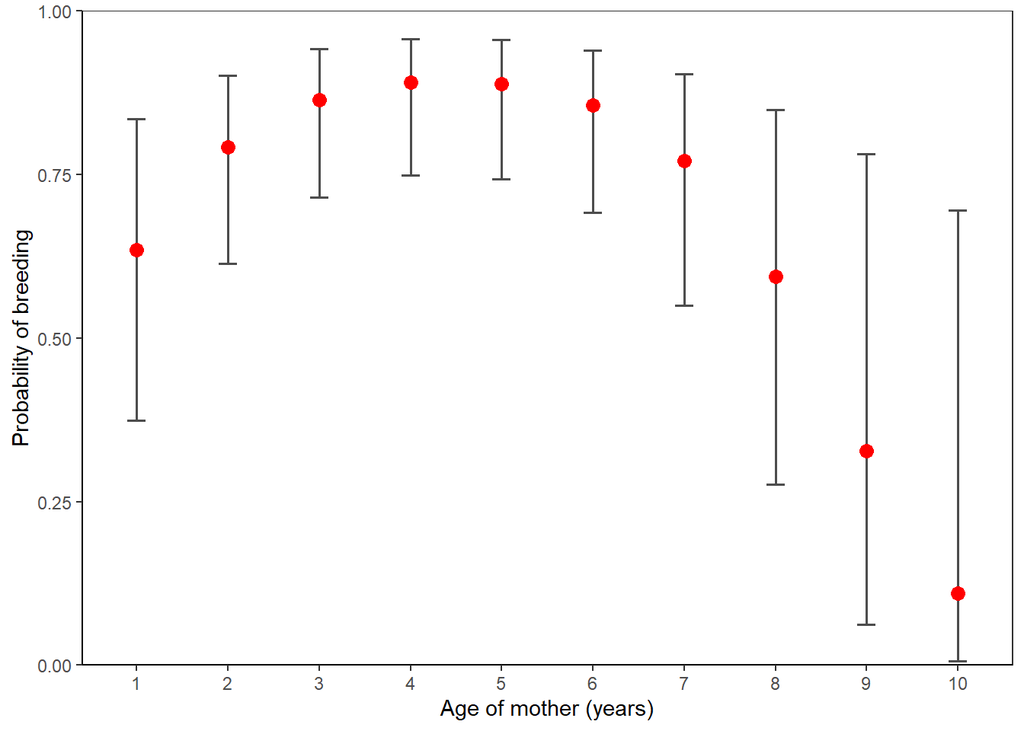

```r
pred_b1 |> tibble() |>
  ggplot(aes(x=x, y= predicted)) +
  geom_errorbar(data=tibble(pred_b1),
                mapping=aes(x=as.factor(x), ymin=conf.low, ymax=conf.high),
                width=0.2, linewidth=0.58, color="grey30") +
  geom_point(color = 'red', size = 3) +
  scale_y_continuous(limits = c(0, 1),
                     expand = c(0, 0),) +
  labs(y="Probability of breeding", x = "Age of mother (years)") +
  theme_bw() +
  theme(axis.line = element_line(colour = "black"),
        panel.grid.major.x = element_blank(),
        panel.grid.minor.x = element_blank(),
        panel.grid.major.y = element_blank(),
        panel.grid.minor.y = element_blank())
```

# 4 Survival of pups in captivity

## 4.1 Data description

The data set includes information on survival of individual Arctic fox pups between emergence from the den until eight to ten weeks of age.

In the data, each mother has a single litter per year. We expect variation in survival among individual mother and years. It is also possible that survival for pups of the same litter is correlated but we do not know this.

## 4.2 Model

Survival were analyzed using a generalized linear mixed model (GLMM) with a binomial distribution and logit link function. The age of the breeding female was included using a quadratic function to allow for a non-linear relationship between pup survival and mother age. The model also included random effects for year and female ID to account for correlation in the data. Due to the dataset’s limited size and the high probability of survival, insufficient information is available to accurately estimate a random effect of litter ID. Additionally, the presence of litters with only one or two pups further complicates the estimation of a random effect associated with litter ID.

The structural form of the binomial model for pup survival:

$$\begin{align}
s_{ij} & = Prob(Y_{ij} = 1|X_{ij}) \\
logit(s_{ij}) & = \beta_0 + \beta_1 X_{ij} + \beta_2 X_{ij}^2 + \delta_i + \gamma_j \\
Y_{ij} & \sim Bern(s_{ij}) \\
\delta_i & \sim N(0, \sigma_\delta) \\
\epsilon_j & \sim N(0, \sigma_\epsilon) \\
\end{align}$$

where $s_{ij}$ is the probability that a pup from mother $i$ in year $j$ survives.

$\delta_i$ is the random effect of mother $i$ and $\gamma_j$ the random effect of year $j$.

## 4.3 Data analysis and results

Reading in data on pup survival in captivity:

```r
sdata <- readRDS('data/survival_captive_breeding_station.rds')
sdata
```

```
# A tibble: 545 × 7
   litter_id pup_id  year mother_age survival litter_size mother_id
   <chr>      <dbl> <dbl>      <dbl>    <dbl>       <dbl>     <dbl>
 1 2007_10       45  2007          3        1           7       639
 2 2007_10       46  2007          3        1           7       639
 3 2007_10       47  2007          3        1           7       639
 4 2007_10       48  2007          3        1           7       639
 5 2007_10       49  2007          3        1           7       639
 6 2007_10       50  2007          3        1           7       639
 7 2007_10       51  2007          3        1           7       639
 8 2007_12       35  2007          3        1           9      1218
 9 2007_12       36  2007          3        1           9      1218
10 2007_12       37  2007          3        1           9      1218
# ℹ 535 more rows
```

```r
sdata$mother_id <- as_factor(sdata$mother_id)
sdata$year <- as_factor(sdata$year)
```

```r
# poly(female_age, 2)
fit_s1 <- glmmTMB(survival ~ poly(mother_age, 2) +
                (1|mother_id) + (1|year),
              data = sdata,
              family = binomial)
```

Predictions survival

```r
## Predictions based on model s1
(pred_s1 <- ggpredict(fit_s1, terms="mother_age [all]"))
```

```
# Predicted probabilities of survival

mother_age | Predicted |       95% CI
-------------------------------------
         1 |      0.92 | [0.68, 0.98]
         2 |      0.97 | [0.86, 0.99]
         3 |      0.98 | [0.92, 1.00]
         4 |      0.99 | [0.94, 1.00]
         5 |      0.99 | [0.95, 1.00]
         6 |      0.99 | [0.94, 1.00]
         7 |      0.98 | [0.90, 1.00]
         9 |      0.92 | [0.43, 0.99]

Adjusted for:
* mother_id = NA (population-level)
*      year = NA (population-level)
```

```
Not all rows are shown in the output. Use `print(..., n = Inf)` to show
  all rows.
```

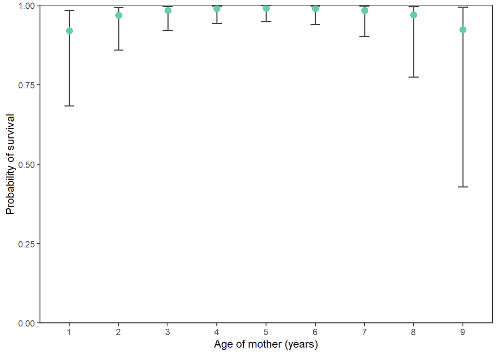

```r
pred_s1 |> tibble() |>
  ggplot(aes(x=x, y= predicted)) +
  geom_errorbar(data=tibble(pred_s1),
                mapping=aes(x=as.factor(x), ymin=conf.low, ymax=conf.high),
                width=0.2, linewidth=0.58, color="grey30") +
  geom_point(color = 'aquamarine3', size = 3) +
  scale_y_continuous(limits = c(0, 1),
                     expand = c(0, 0),) +
  labs(y="Probability of survival", x = "Age of mother (years)") +
  theme_bw() +
  theme(axis.line = element_line(colour = "black"),
        panel.grid.major.x = element_blank(),
        panel.grid.minor.x = element_blank(),
        panel.grid.major.y = element_blank(),
        panel.grid.minor.y = element_blank())
```